# Cars project by Ryan Mansfield

```python
import pandas as pd
import numpy as np

import matplotlib.pyplot as plt
import seaborn as sns

# Removes the limit from the number of displayed columns and rows.
# This is so I can see the entire dataframe when I print it
pd.set_option('display.max_columns', None)
# pd.set_option('display.max_rows', None)
pd.set_option('display.max_rows', 200)
```

```python
df=pd.read_csv('used_cars_data.csv')
```

Let's look at the data set as a whole

```python
np.random.seed(1)
df.sample(n=10)
```

|  | S.No. | Name | Location | Year | Kilometers_Driven | Fuel_Type | Transmission | Owner_Type | Mileage | Engine | Power | Seats | New_Price | Price |
| --- | --- | --- | --- | --- | --- | --- | --- | --- | --- | --- | --- | --- | --- | --- |
| 2397 | 2397 | Ford EcoSport 1.5 Petrol Trend | Kolkata | 2016 | 21460 | Petrol | Manual | First | 17.0 kmpl | 1497 CC | 121.36 bhp | 5.0 | 9.47 Lakh | 6.00 |
| 3777 | 3777 | Maruti Wagon R VXI 1.2 | Kochi | 2015 | 49818 | Petrol | Manual | First | 21.5 kmpl | 1197 CC | 81.80 bhp | 5.0 | 5.44 Lakh | 4.11 |
| 4425 | 4425 | Ford Endeavour 4x2 XLT | Hyderabad | 2007 | 130000 | Diesel | Manual | First | 13.1 kmpl | 2499 CC | 141 bhp | 7.0 | NaN | 6.00 |
| 3661 | 3661 | Mercedes-Benz E-Class E250 CDI Avantgrade | Coimbatore | 2016 | 39753 | Diesel | Automatic | First | 13.0 kmpl | 2143 CC | 201.1 bhp | 5.0 | NaN | 35.28 |
| 4514 | 4514 | Hyundai Xcent 1.2 Kappa AT SX Option | Kochi | 2016 | 45560 | Petrol | Automatic | First | 16.9 kmpl | 1197 CC | 82 bhp | 5.0 | NaN | 6.34 |
| 599 | 599 | Toyota Innova Crysta 2.8 ZX AT | Coimbatore | 2019 | 40674 | Diesel | Automatic | First | 11.36 kmpl | 2755 CC | 171.5 bhp | 7.0 | 28.05 Lakh | 24.82 |
| 186 | 186 | Mercedes-Benz E-Class E250 CDI Avantgrade | Bangalore | 2014 | 37382 | Diesel | Automatic | First | 13.0 kmpl | 2143 CC | 201.1 bhp | 5.0 | NaN | 32.00 |
| 305 | 305 | Audi A6 2011-2015 2.0 TDI Premium Plus | Kochi | 2014 | 61726 | Diesel | Automatic | First | 17.68 kmpl | 1968 CC | 174.33 bhp | 5.0 | NaN | 20.77 |
| 4582 | 4582 | Hyundai i20 1.2 Magna | Kolkata | 2011 | 36000 | Petrol | Manual | First | 18.5 kmpl | 1197 CC | 80 bhp | 5.0 | NaN | 2.50 |
| 5434 | 5434 | Honda WR-V Edge Edition i-VTEC S | Kochi | 2019 | 13913 | Petrol | Manual | First | 17.5 kmpl | 1199 CC | 88.7 bhp | 5.0 | 9.36 Lakh | 8.20 |

```python
print(f'There are {df.shape[0]} rows and {df.shape[1]} columns.')
```

```
There are 7253 rows and 14 columns.
```

Let's see any missing values

```python
df.isnull().sum().sort_values(ascending=False)
```

```
New_Price            6247
Price                1234
Power                 175
Seats                  53
Engine                 46
Mileage                 2
S.No.                   0
Name                    0
Location                0
Year                    0
Kilometers_Driven       0
Fuel_Type               0
Transmission            0
Owner_Type              0
dtype: int64
```

The vast majority of new prices are blanks, lets remove that but save a seperate value so we maybe can compare it to the used price (Price) later

```python
new_price=df['New_Price']
df.drop(['New_Price'], axis=1, inplace=True)
```

we are trying to find a correlation between price and other variables, so replacing NA's with another value would not be wise, lets drop those rows

```python
df=df[~df['Price'].isnull()]
```

Ok, let us make sure that worked.

```python
df.isnull().sum().sort_values(ascending=False)
```

```
Power                143
Seats                 42
Engine                36
Mileage                2
S.No.                  0
Name                   0
Location               0
Year                   0
Kilometers_Driven      0
Fuel_Type              0
Transmission           0
Owner_Type             0
Price                  0
dtype: int64
```

It seems to have worked, we no longer have null values for price Power, seats, engine, and mileage all have missing value. Before we even trat these, we should go back to the overview to see if any have units

```python
np.random.seed(1)
df.sample(n=10)
```

|  | S.No. | Name | Location | Year | Kilometers_Driven | Fuel_Type | Transmission | Owner_Type | Mileage | Engine | Power | Seats | Price |
| --- | --- | --- | --- | --- | --- | --- | --- | --- | --- | --- | --- | --- | --- |
| 2319 | 2319 | Mercedes-Benz E-Class E 350 d | Coimbatore | 2019 | 9312 | Diesel | Automatic | First | 18.0 kmpl | 2987 CC | 258 bhp | 5.0 | 78.80 |
| 3652 | 3652 | Maruti SX4 Zxi with Leather BSIII | Coimbatore | 2008 | 77325 | Petrol | Manual | First | 15.6 kmpl | 1586 CC | 104.68 bhp | 5.0 | 3.51 |
| 2397 | 2397 | Ford EcoSport 1.5 Petrol Trend | Kolkata | 2016 | 21460 | Petrol | Manual | First | 17.0 kmpl | 1497 CC | 121.36 bhp | 5.0 | 6.00 |
| 3536 | 3536 | Honda City V MT | Kochi | 2018 | 11966 | Petrol | Manual | First | 16.8 kmpl | 1497 CC | 116.3 bhp | 5.0 | 10.28 |
| 4400 | 4400 | Volkswagen Polo Petrol Highline 1.6L | Kolkata | 2011 | 46000 | Petrol | Manual | First | 15.26 kmpl | 1598 CC | 103.5 bhp | 5.0 | 2.35 |
| 5347 | 5347 | Maruti Alto 800 2016-2019 LXI | Mumbai | 2018 | 11000 | Petrol | Manual | First | 24.7 kmpl | 796 CC | 47.3 bhp | 5.0 | 3.35 |
| 2852 | 2852 | Mercedes-Benz B Class 2012-2015 B200 Sport CDI | Bangalore | 2014 | 36000 | Diesel | Automatic | First | 15.0 kmpl | 2147 CC | 107.3 bhp | 5.0 | 16.25 |
| 4894 | 4894 | Maruti Baleno Alpha Diesel | Hyderabad | 2017 | 24000 | Diesel | Manual | First | 27.39 kmpl | 1248 CC | 74 bhp | 5.0 | 8.40 |
| 1897 | 1897 | Renault Scala Diesel RxL | Kolkata | 2013 | 40000 | Diesel | Manual | First | 21.64 kmpl | 1461 CC | 84.8 bhp | 5.0 | 4.00 |
| 3663 | 3663 | Hyundai Xcent 1.1 CRDi Base | Pune | 2017 | 73000 | Diesel | Manual | First | 24.4 kmpl | 1120 CC | 71 bhp | 5.0 | 4.50 |

Power engine and mileage all have units. mileage has two but km/kg is the same as kmpl as one one liter shoudl wiehgt 1 kilogram. Lets strip the units Start with power as it is the first, we will replace 'bhp' with ''

```python
import warnings

def fxn():
    warnings.warn("deprecated", DeprecationWarning)

with warnings.catch_warnings():
    warnings.simplefilter("ignore")
    fxn()#let's not show warnings
```

```python
def power_to_num(power):
    """In the power column I'm replacing the terminal 'bph' with
    the empty string and converting to a float. Non-strings are
    np.nans and are kept as np.nans."""
    if isinstance(power, str):
        return float(power.replace('bhp', ''))
    else:
        return np.nan
df['Power'] = df['Power'].apply(power_to_num)
```

Next up is engine, we will replace 'CC' with ''

```python
def engine_to_num(engine):
    """In the weight engine I'm replacing the terminal 'CC' with
    the empty string and converting to a float. Non-strings are
    np.nans and are kept as np.nans."""
    if isinstance(engine, str):
        return float(engine.replace('CC', ''))
    else:
        return np.nan
df['Engine'] = df['Engine'].apply(engine_to_num)
```

Finally, mileage. this has two unites km/kg and kmpl. After some digigng, they appear to be the same unit, both will be repalced with ''

```python
def mileage_to_num(mileage):
    """In the Mileage column I'm replacing the terminal 'km/kg' or 'kmpl' with
    the empty string and converting to a float. Non-strings are
    np.nans and are kept as np.nans."""
    if isinstance(mileage, str):
        return float(mileage.replace('km/kg', '').replace('kmpl',''))
    else:
        return np.nan
df['Mileage'] = df['Mileage'].apply(mileage_to_num)
```

Next we will look at the data frame again just to make sure our transforms worked

```python
np.random.seed(1)
df.sample(n=10)
```

|  | S.No. | Name | Location | Year | Kilometers_Driven | Fuel_Type | Transmission | Owner_Type | Mileage | Engine | Power | Seats | Price |
| --- | --- | --- | --- | --- | --- | --- | --- | --- | --- | --- | --- | --- | --- |
| 2319 | 2319 | Mercedes-Benz E-Class E 350 d | Coimbatore | 2019 | 9312 | Diesel | Automatic | First | 18.00 | 2987.0 | 258.00 | 5.0 | 78.80 |
| 3652 | 3652 | Maruti SX4 Zxi with Leather BSIII | Coimbatore | 2008 | 77325 | Petrol | Manual | First | 15.60 | 1586.0 | 104.68 | 5.0 | 3.51 |
| 2397 | 2397 | Ford EcoSport 1.5 Petrol Trend | Kolkata | 2016 | 21460 | Petrol | Manual | First | 17.00 | 1497.0 | 121.36 | 5.0 | 6.00 |
| 3536 | 3536 | Honda City V MT | Kochi | 2018 | 11966 | Petrol | Manual | First | 16.80 | 1497.0 | 116.30 | 5.0 | 10.28 |
| 4400 | 4400 | Volkswagen Polo Petrol Highline 1.6L | Kolkata | 2011 | 46000 | Petrol | Manual | First | 15.26 | 1598.0 | 103.50 | 5.0 | 2.35 |
| 5347 | 5347 | Maruti Alto 800 2016-2019 LXI | Mumbai | 2018 | 11000 | Petrol | Manual | First | 24.70 | 796.0 | 47.30 | 5.0 | 3.35 |
| 2852 | 2852 | Mercedes-Benz B Class 2012-2015 B200 Sport CDI | Bangalore | 2014 | 36000 | Diesel | Automatic | First | 15.00 | 2147.0 | 107.30 | 5.0 | 16.25 |
| 4894 | 4894 | Maruti Baleno Alpha Diesel | Hyderabad | 2017 | 24000 | Diesel | Manual | First | 27.39 | 1248.0 | 74.00 | 5.0 | 8.40 |
| 1897 | 1897 | Renault Scala Diesel RxL | Kolkata | 2013 | 40000 | Diesel | Manual | First | 21.64 | 1461.0 | 84.80 | 5.0 | 4.00 |
| 3663 | 3663 | Hyundai Xcent 1.1 CRDi Base | Pune | 2017 | 73000 | Diesel | Manual | First | 24.40 | 1120.0 | 71.00 | 5.0 | 4.50 |

It worked! Now lets hist the remaining missing value columns to see if replacing with mean would work

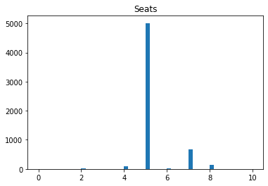

```
1
```

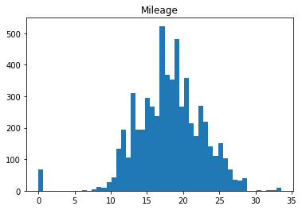

```
68
```

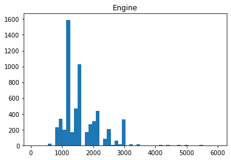

```
0
```

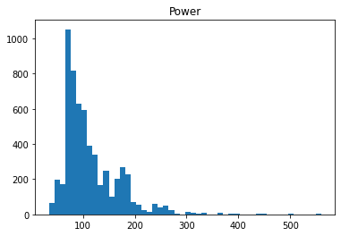

```
0
```

```python
cols_to_plot = ['Seats','Mileage','Engine','Power']
for colname in cols_to_plot:
    plt.hist(df[colname], bins=50)
    plt.title(colname)
    plt.show()
    print(np.sum(df[colname] <= 0))
```

Seats and mileage should be good, engine and power maybe not, let do mean median just to make sure there are normal

```python
df['Seats'].mean()
```

```
5.278735151413753
```

```python
df['Seats'].median()
```

```
5.0
```

Pretty close but I will use median instead of mean as it seems really unlikel a care would have a quarter seat

```python
df['Seats'].fillna(df['Seats'].median(), inplace=True)  # median imputation
df['Seats'].isnull().sum()
```

```
0
```

Time for engine

```python
df['Engine'].mean()
```

```
1621.276449941501
```

```python
df['Engine'].median()
```

```
1493.0
```

Not as close as I'd like, let's log later. Lets do a mean replace. THere is also no reason to think any of these are outliers or bad data as we know some engines are larger than others

```python
df['Engine'].isnull().sum()
```

```
36
```

Mileage next

```python
df['Mileage'].mean()
```

```
18.134960943992073
```

```python
df['Mileage'].median()
```

```
18.15
```

```python
df['Mileage'].fillna(df['Mileage'].mean(), inplace=True)  # mean imputation
df['Mileage'].isnull().sum()
```

```
0
```

Finaly we do power

```python
df['Power'].mean()
```

```
113.25304969366827
```

```python
df['Power'].median()
```

```
97.7
```

Even worse than engine, log this too, lets do a mean replace

```python
df['Power'].isnull().sum()
```

```
143
```

Before we do log of power and engine, lets check the other numerics, in this case thats just kilometes driven

```python
df['Kilometers_Driven'].mean()
```

```
58738.38029573019
```

```python
df['Kilometers_Driven'].median()
```

```
53000.0
```

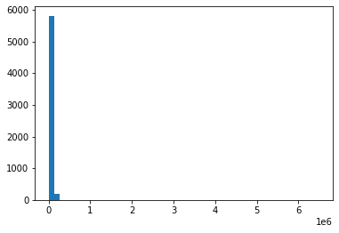

```
0
```

```python
plt.hist(df['Kilometers_Driven'], bins=50)
plt.show()
print(np.sum(df[colname] <= 0))
```

Log this too, what about price?

```python
df['Price'].mean()
```

```
9.479468350224273
```

```python
df['Price'].median()
```

```
5.64
```

Log this too

```python
cols_to_log = ['Engine', 'Power','Kilometers_Driven','Price']
for colname in cols_to_log:
    df[colname + '_log'] = np.log(df[colname] + 1)
df.drop(cols_to_log, axis=1, inplace=True)
df
```

|  | S.No. | Name | Location | Year | Fuel_Type | Transmission | Owner_Type | Mileage | Seats | Engine_log | Power_log | Kilometers_Driven_log | Price_log |
| --- | --- | --- | --- | --- | --- | --- | --- | --- | --- | --- | --- | --- | --- |
| 0 | 0 | Maruti Wagon R LXI CNG | Mumbai | 2010 | CNG | Manual | First | 26.60 | 5.0 | 6.906755 | 4.080246 | 11.184435 | 1.011601 |
| 1 | 1 | Hyundai Creta 1.6 CRDi SX Option | Pune | 2015 | Diesel | Manual | First | 19.67 | 5.0 | 7.367077 | 4.845761 | 10.621352 | 2.602690 |
| 2 | 2 | Honda Jazz V | Chennai | 2011 | Petrol | Manual | First | 18.20 | 5.0 | 7.090077 | 4.496471 | 10.736418 | 1.704748 |
| 3 | 3 | Maruti Ertiga VDI | Chennai | 2012 | Diesel | Manual | First | 20.77 | 7.0 | 7.130099 | 4.497139 | 11.373675 | 1.945910 |
| 4 | 4 | Audi A4 New 2.0 TDI Multitronic | Coimbatore | 2013 | Diesel | Automatic | Second | 15.20 | 5.0 | 7.585281 | 4.954418 | 10.613271 | 2.930660 |
| ... | ... | ... | ... | ... | ... | ... | ... | ... | ... | ... | ... | ... | ... |
| 6014 | 6014 | Maruti Swift VDI | Delhi | 2014 | Diesel | Manual | First | 28.40 | 5.0 | 7.130099 | 4.317488 | 10.217057 | 1.749200 |
| 6015 | 6015 | Hyundai Xcent 1.1 CRDi S | Jaipur | 2015 | Diesel | Manual | First | 24.40 | 5.0 | 7.021976 | 4.276666 | 11.512935 | 1.609438 |
| 6016 | 6016 | Mahindra Xylo D4 BSIV | Jaipur | 2012 | Diesel | Manual | Second | 14.00 | 8.0 | 7.823646 | 4.727388 | 10.915107 | 1.360977 |
| 6017 | 6017 | Maruti Wagon R VXI | Kolkata | 2013 | Petrol | Manual | First | 18.90 | 5.0 | 6.906755 | 4.220977 | 10.736418 | 1.294727 |
| 6018 | 6018 | Chevrolet Beat Diesel | Hyderabad | 2011 | Diesel | Manual | First | 25.44 | 5.0 | 6.842683 | 4.070735 | 10.757924 | 1.252763 |

6019 rows × 13 columns

Lets see if this worked

```python
cols_log = ['Engine_log', 'Power_log','Kilometers_Driven_log','Price_log']
```

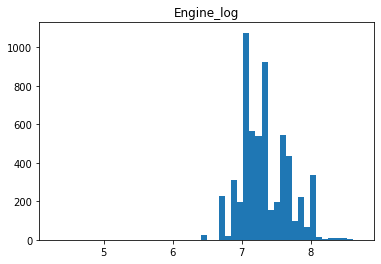

```
0
```

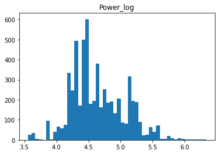

```
0
```

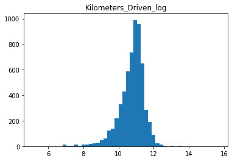

```
0
```

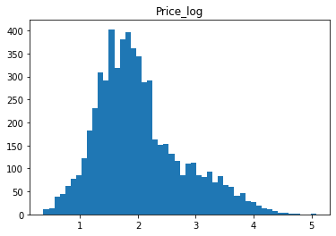

```
0
```

```python
for colname in cols_log:
    plt.hist(df[colname], bins=50)
    plt.title(colname)
    plt.show()
    print(np.sum(df[colname] <= 0))
```

```python
df['Engine_log'].mean()
```

```
7.3315531571436106
```

```python
df['Engine_log'].median()
```

```
7.309212365692763
```

Much better, lets do mean replacement now

```python
df['Engine_log'].fillna(df['Engine_log'].mean(), inplace=True)  # mean imputation
df['Engine_log'].isnull().sum()
```

```
0
```

```python
df['Power_log'].mean()
```

```
4.647980303607528
```

```python
df['Power_log'].median()
```

```
4.592084946439436
```

Much better, lets do mean replacement now

```python
df['Power_log'].fillna(df['Power_log'].mean(), inplace=True)  # mean imputation
df['Power_log'].isnull().sum()
```

```
0
```

```python
df['Kilometers_Driven_log'].mean()
```

```
10.758811994353618
```

```python
df['Kilometers_Driven_log'].median()
```

```
10.87806606028079
```

A lot better again

```python
df['Price_log'].mean()
```

```
2.018428514853132
```

```python
df['Price_log'].median()
```

```
1.8931119634883424
```

A little off, but better Some of the cateogrical data will likely be fine to one hot encode, year for example, but others will likely have far too many vairable names to do this on, serial number for example Let's check to see if we can one hot encode these

```python
df.nunique()
```

```
S.No.                    6019
Name                     1876
Location                   11
Year                       22
Fuel_Type                   5
Transmission                2
Owner_Type                  4
Mileage                   431
Seats                       9
Engine_log                147
Power_log                 370
Kilometers_Driven_log    3093
Price_log                1373
dtype: int64
```

S No and name both have thousands of unique values, this is no good for one hot encoding. Location and year even are high but I will keep for now. Transmission and owner type are both fine. I wish brand was an option here so we could see what brands are most expensive

```python
cols_to_drop=['S.No.','Name']
df.drop(cols_to_drop, axis=1, inplace=True)
```

```python
np.random.seed(1)
df.sample(n=10)
```

|  | Location | Year | Fuel_Type | Transmission | Owner_Type | Mileage | Seats | Engine_log | Power_log | Kilometers_Driven_log | Price_log |
| --- | --- | --- | --- | --- | --- | --- | --- | --- | --- | --- | --- |
| 2319 | Coimbatore | 2019 | Diesel | Automatic | First | 18.00 | 5.0 | 8.002360 | 5.556828 | 9.139167 | 4.379524 |
| 3652 | Coimbatore | 2008 | Petrol | Manual | First | 15.60 | 5.0 | 7.369601 | 4.660416 | 11.255786 | 1.506297 |
| 2397 | Kolkata | 2016 | Petrol | Manual | First | 17.00 | 5.0 | 7.311886 | 4.806968 | 9.973993 | 1.945910 |
| 3536 | Kochi | 2018 | Petrol | Manual | First | 16.80 | 5.0 | 7.311886 | 4.764735 | 9.389908 | 2.423031 |
| 4400 | Kolkata | 2011 | Petrol | Manual | First | 15.26 | 5.0 | 7.377134 | 4.649187 | 10.736418 | 1.208960 |
| 5347 | Mumbai | 2018 | Petrol | Manual | First | 24.70 | 5.0 | 6.680855 | 3.877432 | 9.305741 | 1.470176 |
| 2852 | Bangalore | 2014 | Diesel | Automatic | First | 15.00 | 5.0 | 7.672292 | 4.684905 | 10.491302 | 2.847812 |
| 4894 | Hyderabad | 2017 | Diesel | Manual | First | 27.39 | 5.0 | 7.130099 | 4.317488 | 10.085851 | 2.240710 |
| 1897 | Kolkata | 2013 | Diesel | Manual | First | 21.64 | 5.0 | 7.287561 | 4.452019 | 10.596660 | 1.609438 |
| 3663 | Pune | 2017 | Diesel | Manual | First | 24.40 | 5.0 | 7.021976 | 4.276666 | 11.198228 | 1.704748 |

Ok the data are good for One Hot encoding now

lets normalize the data to make it easier to see trends I ran this once without normalizing and it was a little hard to make a lot of since of it. It will be easiest to zscore all the numeric values for input, so milieage,seats,engine_log, power_log, and miometers_driven_log

```python
from sklearn.preprocessing import StandardScaler
std_scaler = StandardScaler()
cols_to_z_score=['Mileage','Seats','Engine_log','Power_log','Kilometers_Driven_log']


for colname in cols_to_z_score:
    df[colname]=std_scaler.fit_transform(df[[colname]])
```

```python
y = df["Price_log"]
```

```python
X=df.drop(['Price_log'],axis=1,inplace=False)
```

```python
X = pd.get_dummies(
    X,
    columns=X.select_dtypes(include=["object", "category"]).columns.tolist(),
    drop_first=False,
)
```

Instead of makign each year a categorical, I want to see how old it is (i.e how many years ago it was made)

```python
X['Year']=max(X['Year'])-X['Year']
X['Year']
X
```

|  | Year | Mileage | Seats | Engine_log | Power_log | Kilometers_Driven_log | Location_Ahmedabad | Location_Bangalore | Location_Chennai | Location_Coimbatore | Location_Delhi | Location_Hyderabad | Location_Jaipur | Location_Kochi | Location_Kolkata | Location_Mumbai | Location_Pune | Fuel_Type_CNG | Fuel_Type_Diesel | Fuel_Type_Electric | Fuel_Type_LPG | Fuel_Type_Petrol | Transmission_Automatic | Transmission_Manual | Owner_Type_First | Owner_Type_Fourth & Above | Owner_Type_Second | Owner_Type_Third |
| --- | --- | --- | --- | --- | --- | --- | --- | --- | --- | --- | --- | --- | --- | --- | --- | --- | --- | --- | --- | --- | --- | --- | --- | --- | --- | --- | --- | --- |
| 0 | 9 | 1.847799 | -0.343293 | -1.253063 | -1.393073 | 0.594714 | 0 | 0 | 0 | 0 | 0 | 0 | 0 | 0 | 0 | 1 | 0 | 1 | 0 | 0 | 0 | 0 | 0 | 1 | 1 | 0 | 0 | 0 |
| 1 | 4 | 0.335077 | -0.343293 | 0.104788 | 0.485302 | -0.192070 | 0 | 0 | 0 | 0 | 0 | 0 | 0 | 0 | 0 | 0 | 1 | 0 | 1 | 0 | 0 | 0 | 0 | 1 | 1 | 0 | 0 | 0 |
| 2 | 8 | 0.014197 | -0.343293 | -0.712302 | -0.371765 | -0.031290 | 0 | 0 | 1 | 0 | 0 | 0 | 0 | 0 | 0 | 0 | 0 | 0 | 0 | 0 | 0 | 1 | 0 | 1 | 1 | 0 | 0 | 0 |
| 3 | 7 | 0.575192 | 2.137237 | -0.594247 | -0.370124 | 0.859135 | 0 | 0 | 1 | 0 | 0 | 0 | 0 | 0 | 0 | 0 | 0 | 0 | 1 | 0 | 0 | 0 | 0 | 1 | 1 | 0 | 0 | 0 |
| 4 | 6 | -0.640661 | -0.343293 | 0.748442 | 0.751918 | -0.203362 | 0 | 0 | 0 | 1 | 0 | 0 | 0 | 0 | 0 | 0 | 0 | 0 | 1 | 0 | 0 | 0 | 1 | 0 | 0 | 0 | 1 | 0 |
| ... | ... | ... | ... | ... | ... | ... | ... | ... | ... | ... | ... | ... | ... | ... | ... | ... | ... | ... | ... | ... | ... | ... | ... | ... | ... | ... | ... | ... |
| 6014 | 5 | 2.240714 | -0.343293 | -0.594247 | -0.810942 | -0.756983 | 0 | 0 | 0 | 0 | 1 | 0 | 0 | 0 | 0 | 0 | 0 | 0 | 1 | 0 | 0 | 0 | 0 | 1 | 1 | 0 | 0 | 0 |
| 6015 | 4 | 1.367570 | -0.343293 | -0.913184 | -0.911109 | 1.053720 | 0 | 0 | 0 | 0 | 0 | 0 | 1 | 0 | 0 | 0 | 0 | 0 | 1 | 0 | 0 | 0 | 0 | 1 | 1 | 0 | 0 | 0 |
| 6016 | 7 | -0.902604 | 3.377503 | 1.451566 | 0.194845 | 0.218387 | 0 | 0 | 0 | 0 | 0 | 0 | 1 | 0 | 0 | 0 | 0 | 0 | 1 | 0 | 0 | 0 | 0 | 1 | 0 | 0 | 1 | 0 |
| 6017 | 6 | 0.166997 | -0.343293 | -1.253063 | -1.047755 | -0.031290 | 0 | 0 | 0 | 0 | 0 | 0 | 0 | 0 | 1 | 0 | 0 | 0 | 0 | 0 | 0 | 1 | 0 | 1 | 1 | 0 | 0 | 0 |
| 6018 | 8 | 1.594587 | -0.343293 | -1.442060 | -1.416411 | -0.001241 | 0 | 0 | 0 | 0 | 0 | 1 | 0 | 0 | 0 | 0 | 0 | 0 | 1 | 0 | 0 | 0 | 0 | 1 | 1 | 0 | 0 | 0 |

6019 rows × 28 columns

Ok so that looks a lot better, lets split into training and testing,

```
<function matplotlib.pyplot.show(close=None, block=None)>
```

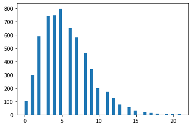

```python
plt.hist(X['Year'], bins=50)#is it mostly normal? I'm not surethat matters
plt.show
```

```python
from sklearn.model_selection import train_test_split
x_train, x_test, y_train, y_test = train_test_split(X, y, test_size=0.3, random_state=1) # I will just use the defalt sizes
```

Import the lin regression component

```python
from sklearn.linear_model import LinearRegression
lin_reg_model = LinearRegression()

lin_reg_model.fit(x_train, y_train)
```

```
LinearRegression(copy_X=True, fit_intercept=True, n_jobs=None, normalize=False)
```

Let's look at the regression and it's coefficients

```python
coef_df = pd.DataFrame(
    np.append(lin_reg_model.coef_, lin_reg_model.intercept_),
    index=x_train.columns.tolist() + ["Intercept"],
    columns=["Coefficients"],
)
coef_df
```

|  | Coefficients |
| --- | --- |
| Year | -0.085291 |
| Mileage | -0.046605 |
| Seats | -0.015336 |
| Engine_log | 0.100525 |
| Power_log | 0.339961 |
| Kilometers_Driven_log | -0.077824 |
| Location_Ahmedabad | -0.019830 |
| Location_Bangalore | 0.132294 |
| Location_Chennai | 0.008409 |
| Location_Coimbatore | 0.128397 |
| Location_Delhi | -0.043717 |
| Location_Hyderabad | 0.127732 |
| Location_Jaipur | -0.010000 |
| Location_Kochi | -0.014977 |
| Location_Kolkata | -0.205321 |
| Location_Mumbai | -0.063972 |
| Location_Pune | -0.039015 |
| Fuel_Type_CNG | -0.104945 |
| Fuel_Type_Diesel | -0.087868 |
| Fuel_Type_Electric | 0.677264 |
| Fuel_Type_LPG | -0.145818 |
| Fuel_Type_Petrol | -0.338633 |
| Transmission_Automatic | 0.144973 |
| Transmission_Manual | -0.144973 |
| Owner_Type_First | 0.037873 |
| Owner_Type_Fourth & Above | 0.027407 |
| Owner_Type_Second | -0.020621 |
| Owner_Type_Third | -0.044660 |
| Intercept | 2.733120 |

We will come back to this at the end, but I do find these interesting

```python
from sklearn.metrics import mean_absolute_error, mean_squared_error, r2_score
# function to compute adjusted R-squared
def adj_r2_score(predictors, targets, predictions):
    r2 = r2_score(targets, predictions)
    n = predictors.shape[0]
    k = predictors.shape[1]
    return 1 - ((1 - r2) * (n - 1) / (n - k - 1))


# function to compute MAPE
def mape_score(targets, predictions):
    return np.mean(np.abs(targets - predictions) / targets) * 100


# function to compute different metrics to check performance of a regression model
def model_performance_regression(model, predictors, target):
    """
    Function to compute different metrics to check regression model performance

    model: regressor
    predictors: independent variables
    target: dependent variable
    """

    # predicting using the independent variables
    pred = model.predict(predictors)

    r2 = r2_score(target, pred)  # to compute R-squared
    adjr2 = adj_r2_score(predictors, target, pred)  # to compute adjusted R-squared
    rmse = np.sqrt(mean_squared_error(target, pred))  # to compute RMSE
    mae = mean_absolute_error(target, pred)  # to compute MAE
    mape = mape_score(target, pred)  # to compute MAPE

    # creating a dataframe of metrics
    df_perf = pd.DataFrame(
        {
            "RMSE": rmse,
            "MAE": mae,
            "R-squared": r2,
            "Adj. R-squared": adjr2,
            "MAPE": mape,
        },
        index=[0],
    )

    return df_perf
# Checking model performance on train set
print("Training Performance\n")
lin_reg_model_train_perf = model_performance_regression(lin_reg_model, x_train, y_train)
lin_reg_model_train_perf
```

```
Training Performance
```

|  | RMSE | MAE | R-squared | Adj. R-squared | MAPE |
| --- | --- | --- | --- | --- | --- |
| 0 | 0.267378 | 0.200851 | 0.871567 | 0.870708 | 11.650499 |

```python
df['Price_log'].mean()
```

```
2.018428514853132
```

```python
df['Price_log'].median()
```

```
1.8931119634883424
```

That is not too bad at all, with this and MAPE we bet an error around 10% up to 11.65%. This is by no means negligable but it is a good start

I first tried this without rnning log on price and it did not turn out nearly as well, so I would recommend any futrue uses of similiar data sets also log the price and then take e to the power of the result to find the price

Lets circle back to the coefficients

```python
coef_df = pd.DataFrame(
    np.append(lin_reg_model.coef_, lin_reg_model.intercept_),
    index=x_train.columns.tolist() + ["Intercept"],
    columns=["Coefficients"],
)
coef_df
```

|  | Coefficients |
| --- | --- |
| Year | -0.085291 |
| Mileage | -0.046605 |
| Seats | -0.015336 |
| Engine_log | 0.100525 |
| Power_log | 0.339961 |
| Kilometers_Driven_log | -0.077824 |
| Location_Ahmedabad | -0.019830 |
| Location_Bangalore | 0.132294 |
| Location_Chennai | 0.008409 |
| Location_Coimbatore | 0.128397 |
| Location_Delhi | -0.043717 |
| Location_Hyderabad | 0.127732 |
| Location_Jaipur | -0.010000 |
| Location_Kochi | -0.014977 |
| Location_Kolkata | -0.205321 |
| Location_Mumbai | -0.063972 |
| Location_Pune | -0.039015 |
| Fuel_Type_CNG | -0.104945 |
| Fuel_Type_Diesel | -0.087868 |
| Fuel_Type_Electric | 0.677264 |
| Fuel_Type_LPG | -0.145818 |
| Fuel_Type_Petrol | -0.338633 |
| Transmission_Automatic | 0.144973 |
| Transmission_Manual | -0.144973 |
| Owner_Type_First | 0.037873 |
| Owner_Type_Fourth & Above | 0.027407 |
| Owner_Type_Second | -0.020621 |
| Owner_Type_Third | -0.044660 |
| Intercept | 2.733120 |

Year: slight negative corrleation between year and price. Nothing that is concerning

Mileage: we see only a slightly negative relationship with price, perhaps don't concern ourselves with buying cars with high milage

Seats: almost no impact, do not concenr ourselves here

Engine: larger engines appear to sell for more. With the log being considered I think buying cars with larger engines may be worth while

Power: with the log this still has a very high impact. People want powerful cars and will pay more for them

Kilomets driven: we alos took log here, I would recommend looking at this a little as it seems those with very high usage will decrease in value. This decrease is close to the increase ofengine size so I think it is somehting to be aware of. It is however important to remember we may get better deals with cars with high mileage

Location: Banaglor, Coimbatore, and Hyderabad fetch higher prices. Kolkata fetches lower prices

Fuel type: electric seems to be prefered and CNG, Petrol, and LPG all seem to have a negative impact of price